# Literary Sentiment Analysis

Author

Zane Mohammad

## Libraries

```r
library(gutenbergr)
library(tidytext)
library(dplyr)
library(tidyr)
library(ggplot2)
library(patchwork)
```

This nifty `patchwork` library can help us combine graphs to make side-by-side visualization possible

## Functions

Lets make some funcitons to expedite this process. When downloading dataframes, we will need to use the `gutenberg_download()` function, the unnest the tokens with `unnest_tokens(word, text)`, then remove stop words and unused columns.

This function will take in one parameter for the ID number of the text and return a dataframe of just the selected words from that text.

```r
book_load <- function(id_num) {
  gutenberg_download(id_num, mirror = "http://mirror.csclub.uwaterloo.ca/gutenberg") |>
  unnest_tokens(word, text) |> anti_join(stop_words) |> select(word)
}
## In case the first fails
book_load2 <- function(id_num) {
  gutenberg_download(id_num, mirror = "...") |>
  unnest_tokens(word, text) |> anti_join(stop_words) |> select(word)
}
```

Lets also make a function that takes this dataframe and graphs it. We start by breaking it up into 100 chunks. We will then multiply by `size_coefficient` to ensure that the differences in text length do not affect the results.

The function will take in a dataframe and output a graph.

```r
graph_book <- function(df, title_str) {
  size_coefficient <- (1000/nrow(df))
  df_sentiment <- df |>
    inner_join(get_sentiments("bing"), by = "word") |>
    mutate(proportion = row_number() / n()) |>
    mutate(chunk = ceiling(proportion * 100)) |>
    group_by(chunk) |>
    summarise(
      sentiment_score = ((sum(sentiment == "positive") - sum(sentiment == "negative"))*size_coefficient),
      proportion = first(proportion),
      .groups = "drop"
    )
  ggplot(df_sentiment, aes(x = proportion, y = sentiment_score, fill = sentiment_score > 0)) +
    geom_bar(stat = "identity", na.rm = TRUE) +
    coord_cartesian(ylim = c(-1.5, 1)) +
    scale_y_continuous(breaks = seq(-1.5, 1, by = 0.2)) +
    scale_x_continuous(
      limits = c(0, 1),
      labels = scales::percent_format(),
      breaks = seq(0, 1, 0.1)
    ) +
    scale_fill_manual(
      values = c("red", "blue"),
      labels = c("Negative", "Positive"),
      name = "Sentiment"
    ) +
    labs(
      title = paste(title_str, "Sentiment"),
      x = "Progrssion",
      y = "Sentiment"
    ) +
    theme_minimal() +
    theme(axis.text.x = element_text(angle = 45, hjust = 1))
}
```

This function will get the same data that is in the graph as a dataframe.

The function takes in a dataframe parameter and returns a dataframe on sentiments and proportions

```r
sentiment_df <- function(df){
  size_coefficient <- (1000/nrow(df))
  df <- df |>
    inner_join(get_sentiments("bing"), by = "word") |>
    mutate(proportion = row_number() / n()) |>
    mutate(chunk = ceiling(proportion * 100)) |>
    group_by(chunk) |>
    summarise(
      sentiment_score = ((sum(sentiment == "positive") - sum(sentiment == "negative")) *
                           size_coefficient),
      proportion = first(proportion),
      .groups = "drop"
    )
  return(df)
}
```

And a function to combine multiple dataframes into a single plot. This graph will plot the points of the sentiment values of all of the included dataframes onto a single graph and draw a curve to fit the plot.

```r
plot_multiple <- function(df1, df2, df3, df4, title_str){
  combined_df <- bind_rows(bind_rows(df1, df2), bind_rows(df3, df4))
  ggplot() +
    geom_point(data = df1, aes(x = proportion, y = sentiment_score, color = "1")) +
    geom_point(data = df2, aes(x = proportion, y = sentiment_score, color = "2")) +
    geom_point(data = df3, aes(x = proportion, y = sentiment_score, color = "3")) +
    geom_point(data = df4, aes(x = proportion, y = sentiment_score, color = "4")) +
# Individual Lines
    geom_line(data = df1,aes(x = proportion, y = sentiment_score), stat = "smooth", se = FALSE, alpha = 0.7, color = "1") +
    geom_line(data = df2,aes(x = proportion, y = sentiment_score), stat = "smooth", se = FALSE, alpha = 0.7, color = "2") +
    geom_line(data = df3,aes(x = proportion, y = sentiment_score), stat = "smooth", se = FALSE, alpha = 0.7, color = "3") +
    geom_line(data = df4,aes(x = proportion, y = sentiment_score), stat = "smooth", se = FALSE, alpha = 0.7, color = "4") +
# Combined Lines
    geom_smooth(data = combined_df,aes(x = proportion, y = sentiment_score), method = "loess", se = FALSE, size = 5, linetype = "dotted") +
# Graph
    coord_cartesian(ylim = c(-1, 1)) +
    scale_y_continuous(breaks = seq(-1, 1, by = 0.2)) +
    labs(x = "X-axis Label", y = "Y-axis Label", title = title_str) +
    theme_minimal()
}
```

## Data

Let’s get data from a variety of literary genres and see how they compare. Let’s compile texts from the following genres.

- Philosophies
- Comedies
- Epics
- Tragedies

```r
# Philosophy
symbolic_logic <- book_load(28696)
practical_critique <- book_load(5683)
categories <- book_load(2412)
republic <- book_load(1497)
# Fiction
  # Comedies
don_quixote <- book_load(996)
tristram_shandy <- book_load(39270)
divine_comedy <- book_load(8800)
inspector <- book_load(3735)
  # Epics
illiad <- book_load(6130)
odyssey <- book_load(3160)
gilgamesh <- book_load(11000)
paradise_lost <- book_load(20)
  # Tragedies
othello <- book_load(1531)
frankenstein <- book_load(41445)
anna_karenina <- book_load(1399)
moby_dick <- book_load(2701)
```

## Graphing Books

#### Philosophy Graphs

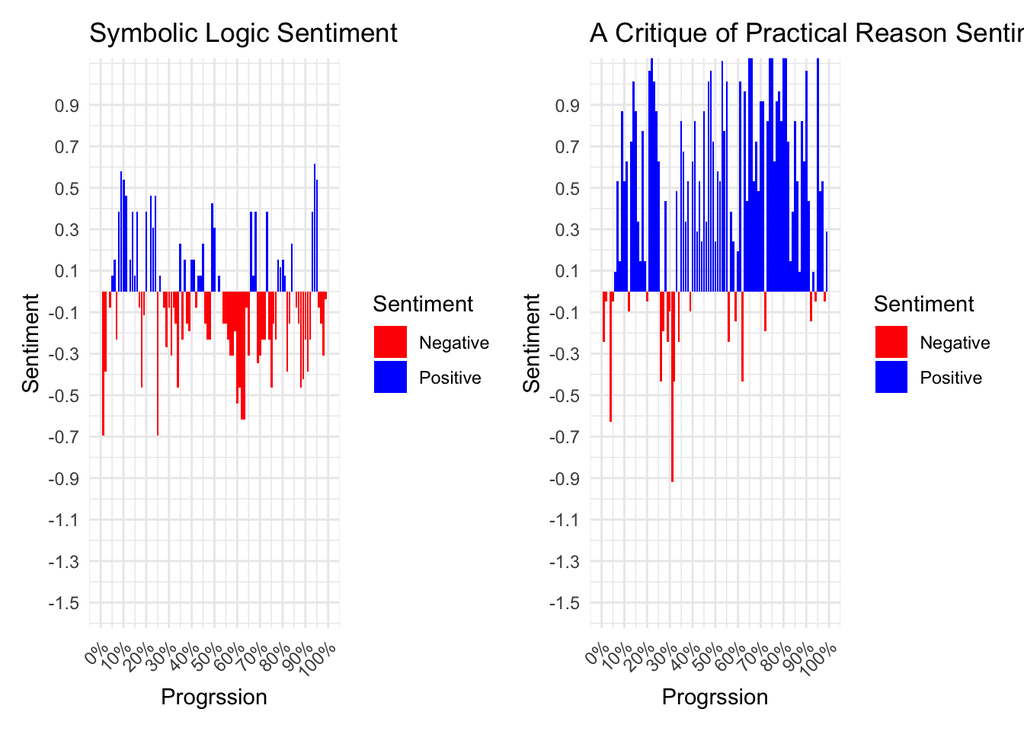

```r
symbolic_logic |>
  graph_book("Symbolic Logic") +
  practical_critique |>
  graph_book("A Critique of Practical Reason")
```

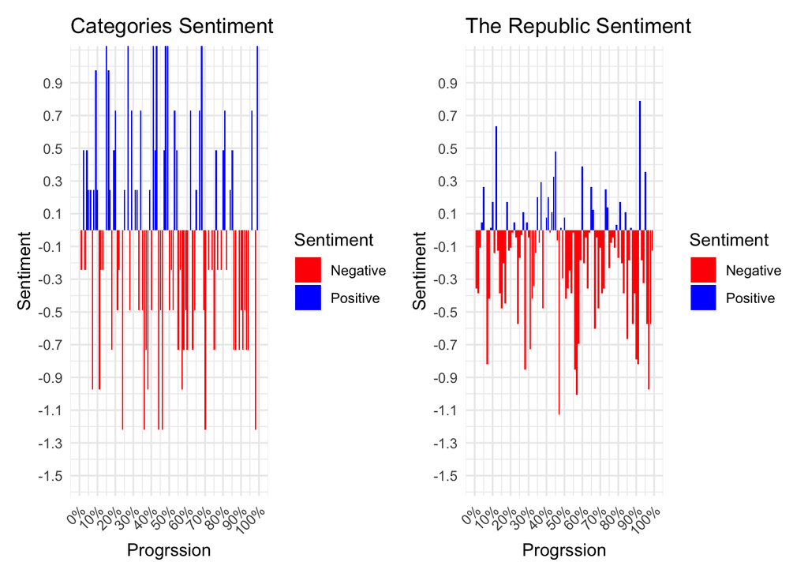

```r
categories |>
  graph_book("Categories") +
  republic |>
  graph_book("The Republic")
```

#### Comedy Graphs

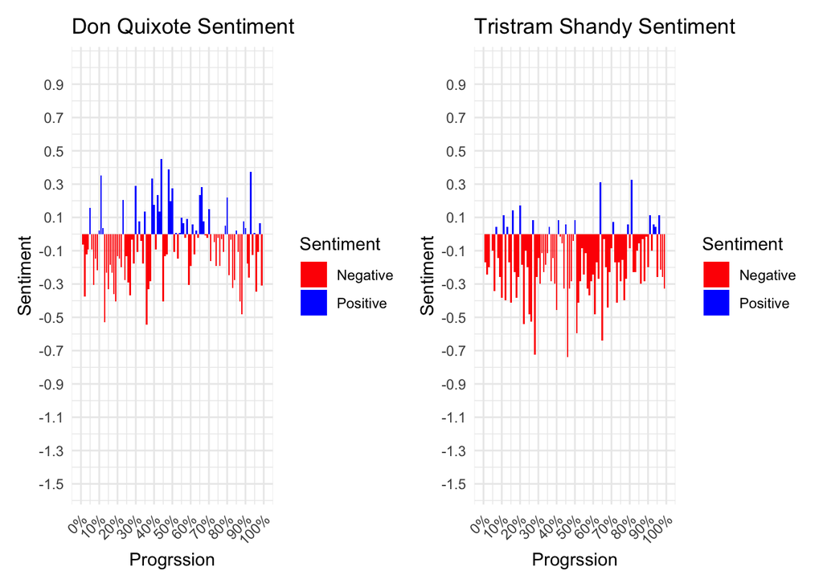

```r
don_quixote |>
  graph_book("Don Quixote") +
  tristram_shandy |>
  graph_book("Tristram Shandy")
```

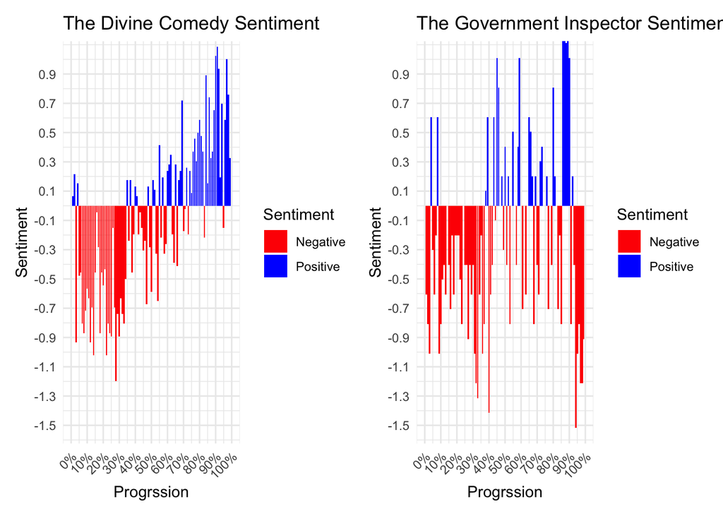

```r
divine_comedy |>
  graph_book("The Divine Comedy") +
  inspector |>
  graph_book("The Government Inspector")
```

#### Epic Graphs

```r
illiad |>
  graph_book("The Illiad") +
  odyssey |>
  graph_book("The Odyssey")
```

[figure not shown]

```r
gilgamesh |>
  graph_book("Gilgamesh") +
  paradise_lost |>
  graph_book("Paradise Lost")
```

[figure not shown]

#### Tragedy Graphs

```r
othello |>
  graph_book("Othello") +
  frankenstein |>
  graph_book("Frankenstein")
```

[figure not shown]

```r
anna_karenina |>
  graph_book("Anna Karenina") +
  moby_dick |>
  graph_book("Moby Dick")
```

[figure not shown]

Tragedy books appear to have the strongest sentiment of any of the given genres. As expected, most of this sentiment is negative.

## Genre Graphs

### Combined Graphs

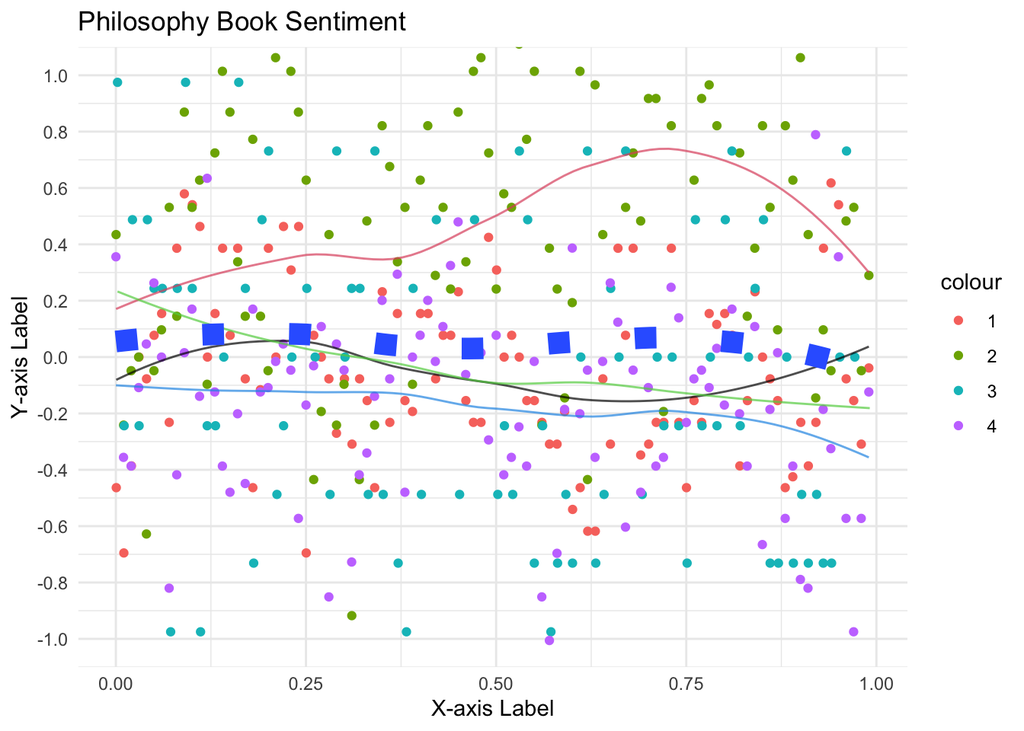

```r
plot_multiple(sentiment_df(symbolic_logic), sentiment_df(practical_critique), sentiment_df(categories), sentiment_df(republic), "Philosophy Book Sentiment")
```

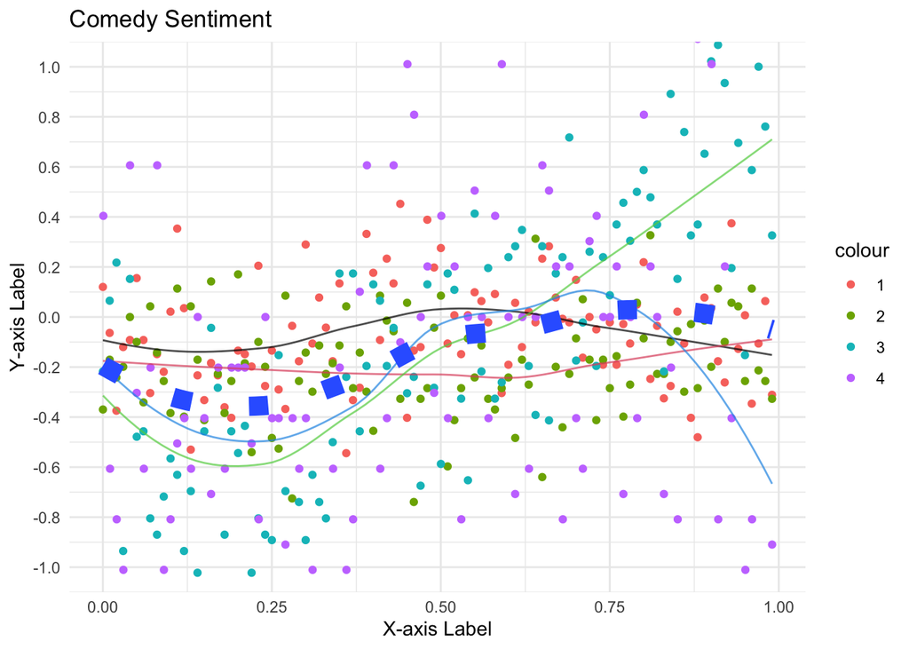

```r
plot_multiple(sentiment_df(don_quixote), sentiment_df(tristram_shandy), sentiment_df(divine_comedy), sentiment_df(inspector), "Comedy Sentiment")
```

```r
plot_multiple(sentiment_df(illiad), sentiment_df(odyssey), sentiment_df(gilgamesh), sentiment_df(paradise_lost), "Epic Sentiment")
```

[figure not shown]

```r
plot_multiple(sentiment_df(othello), sentiment_df(frankenstein), sentiment_df(anna_karenina), sentiment_df(moby_dick), "Tragedy Sentiment")
```

[figure not shown]

From these combined graphs we can assess the strength of sentiment (by the graph’s range), and the precision of the sentiment (by the variation in the graphs, since the graphs will be flatter the less of a pattern there is).

## Conclusions

#### Philosophy Books

It looks like, while philosophers are generally more optimisic that fiction-writers, there is no pattern of sentiment that is indicative of philosophy texts.

#### Comedies

This trend reminds us of Aristotle’s remark in The Poetics, that comedies are nothing more than tales of bad fates upon bad men.

#### Epics

In many way the Epic Trend can be described as the opposite of the Comic Trend. They begin with a trend towards positive sentiment and end with a trend towards positive sentiment, with a long trend towards negative sentiment in between.

#### Tragedies

Tragedies have the strongest trend lines, and strongest average sentiments. Almost all of the aggregate trend line progresses towards more negative sentiment. However it appear that in the particular trend lines, there exist more distinct reversals of this trend in the middle.